# Comparison between sequences at 100% identity

References for taxonomical assignation: PR2 vs MareChiara

Lucia Campese

September 2020

### Aim

The Aim is to compare distribution, biogeography and taxonomic composition of the metabarcoding V4 dataset taxonomically assigned to the genus *Pseudonitzschia* using two different reference databases:

1. A revised version of the **PR2 database** (Guillouet al., 2013) for which the Chlorophyta sequences had been checked against the latest taxonomy (Traginet al., 2016) [info to be confirmed] => **TARA-PR2** ;
2. A selection of 27 *Pseudonitzschia* species sequences (from Valeria R.) from **MareChiara** V4 dataset => **TARA-MC**

### Dataset

##### Data: TARA Oceans and Tara Oceans Polar circle metabarcording (V4)

##### Taxon: *Pseudonitzschia*

##### Geographic scale: Global

```bash
#1. Extract Pseudonitzschia sequences from the total V4 dataset

pwd: ~/Data/metaB/V4/TARA_exploration

#srun grep "Pseudo-nitzschia" /home/lcampese/Data/metaB/V4/18S_V4_1191_samples.results | awk '{print $1}' | sort > Pn_sequenceId.txt &

srun grep "Pseudo-nitzschia" /home/lcampese/Data/metaB/V4/18S_V4_1191_samples.results > 18S_V4_1191_samples_Pn.results &

###30946 sequences
```

### Workflow

#### **Building datasets**

##### a) **TARA-PR2**

1. Check the distribution of the identity percentage of amplicons to the reference dataset (PR2)

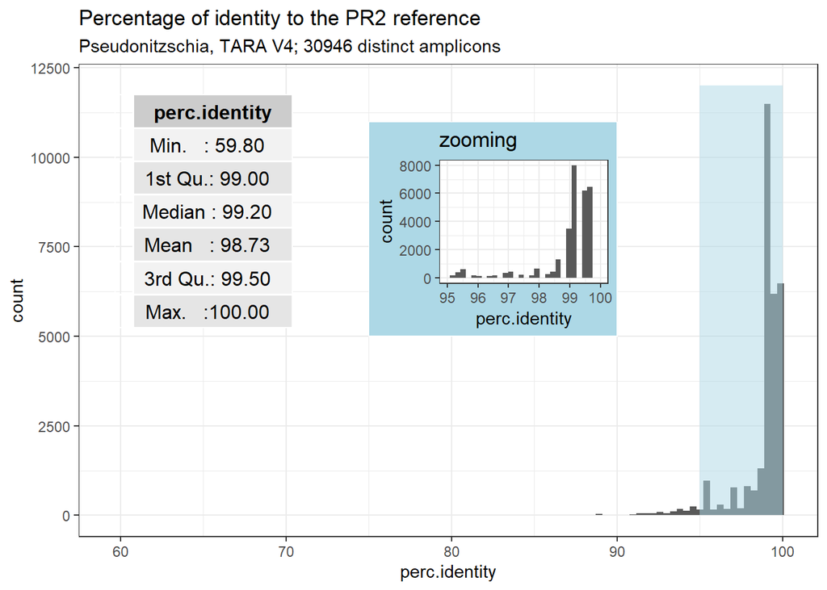

```r
library(data.table)
library(tidyverse)
library(gridExtra)


load("C:/Users/Userszn/Documents/PhD/script/Pseudonitzschia/metaB/V4/Pn_tax.RData")

#Pn_tax.RData contains seqId | sampleId | counts, per each of the 20956 seqIds assigned as Pseudonitzschia

Percid <-
  Pn_tax %>%
  select(perc.identity) %>%
  summary()


mainplot <-Pn_tax %>% ggplot +
  aes(x = perc.identity,
      fill = tot.numb.reads) +
  geom_histogram(bins = 100) +
  theme_bw() +
  # xlim(90,100) +
  annotation_custom(tableGrob(Percid), xmin=60, xmax=70, ymin=5000, ymax=12000) +
  ggtitle("Percentage of identity to the PR2 reference",
          subtitle= paste0("Pseudonitzschia, TARA V4; ",
                           n_distinct(Pn_tax$seqId),
                           " distinct amplicons")) +
  annotate("rect", xmin=95, xmax=100, ymin=0, ymax=12000, fill="lightblue", alpha = 0.5)


zoomplot <- Pn_tax %>% ggplot +
  aes(x = perc.identity,
      fill = tot.numb.reads) +
  geom_histogram() +
  theme_bw() +
  xlim(95,100) +
  ggtitle("zooming") +
  #theme(panel.background = element_rect(fill = 'lightblue', colour = 'lightblue')) +
  theme(plot.background = element_rect(fill = 'lightblue'))



mainplot + annotation_custom(ggplotGrob(zoomplot), xmin = 75, xmax = 90,
                             ymin = 5000, ymax = 11000)
```

The identity percentage ranges from 59.8 to 100, but almost all sequences show a value around 99% identity to the reference database.

2. Extract from the dataset only the sequences with 100% identity to PR2 database

```r
#take only sequences with at least 3 reads (seen three times in the whole dataset) [*]
srun awk '$2>2' 18S_V4_1191_samples_Pn.results > 18S_V4_1191_samples_Pn_3readsmin.results &

#wc -l: 25453 18S_V4_1191_samples_Pn_3readsmin.results
#wc -l: 30946 18S_V4_1191_samples_Pn.results


#[*]as adviced by Nicholas Henry. Note: he also suggests to take reads appearing in at least 2 stations, but this will be done after
  #(when integrating the distribution info)


#Take only 100% pid sequences (pid is 3rd column)
awk '$3>99.99' 18S_V4_1191_samples_Pn_3readsmin.results > 18S_V4_1191_samples_Pn_pid100_3readsmin.results

#they are 17

#Extract only seq ids (column 1)
awk '{print $1}' 18S_V4_1191_samples_Pn_pid100_3readsmin.results > 18S_V4_1191_samples_Pn_pid100_3readsmin_seqid.txt

#use the retrieved 17 sequence Ids to subset the distr file (i.e. the one
#containing seqId|sampleId|readcounts

srun grep -Ff 18S_V4_1191_samples_Pn_pid100_3readsmin_seqid.txt ~/Data/metaB/V4/18S_V4_1191_samples.distr > 18S_V4_1191_samples_Pn_pid100_3readsmin.distr &


#the final output is made by 17 different sequences
```

There are **17** different **sequences** assigned to *Pseudonitzschia* species with a **100% identity** to PR2 database and occurring at least **3 times** in the dataset.

3. Add the environmental information for the selected 17 sequences

Note: All sequences have length >380 bp: this is sequence length and not query cover. However, the taxonomic assignment has been done using vsearch with the usearch_global option. It is global alignment so the query cover is always 100% (mail from Nicolas).

```r
library(data.table)
library(tidyverse)

Pn_identity100.distr <- fread("C:/Users/Userszn/Documents/PhD/script/Pseudonitzschia/metaB/V4/18S_V4_1191_samples_Pn_pid100_3readsmin.distr")

Pn_identity100.tax <- fread("C:/Users/Userszn/Documents/PhD/script/Pseudonitzschia/metaB/V4/18S_V4_1191_samples_Pn_pid100_3readsmin.results", header = F, sep = "\t")

###ADD LENGTH INFO
length.info <-fread("C:/Users/Userszn/Documents/PhD/script/Pseudonitzschia/metaB/V4/18S_V4_1191_samples_Pn_pid100_3readsmin_seqid_length_seq_clean")


Pn_identity100.tax.length <- length.info %>%
  rename(length = V2) %>%
  left_join(Pn_identity100.tax)


Pn_identity100.distr.tax.length <- inner_join(Pn_identity100.distr, Pn_identity100.tax.length, by = "V1") %>%
  select(-V2.y)

colnames(Pn_identity100.distr.tax.length) <- c("seqId", "sample", "readcounts", "length", "perc.identity", "lineage", "idpr2")


env <- fread("C:/Users/Userszn/Documents/PhD/script/Pseudonitzschia/metaB/V4/18S_V4_1191_samples_context.tsv")

Pn_identity100.distr.tax.env <- inner_join(Pn_identity100.distr.tax.length, env)

Pn_identity100.distr.tax.env1 <- splitstackshape::cSplit(Pn_identity100.distr.tax.env, "lineage", "|") %>%
  select(seqId:minimum.generation.time.h,lineage_13) %>%
  mutate(species = case_when(lineage_13 == "*" ~ "Pseudo-nitzschia+unknown",
                             TRUE ~ as.character(lineage_13))) %>%
  select(-lineage_13) %>%
  splitstackshape::cSplit("species", "+") %>%
  rename(species = species_2) %>%
  group_by(seqId) %>%
  ungroup() %>%
  select(seqId, length, sample, readcounts, perc.identity:idpr2, species, Station.label:Depth.chloro.max)


final_tara_pr2<- Pn_identity100.distr.tax.env1 %>%
  select(seqId, length, species, sample, readcounts, Station.label:Depth.chloro.max) %>%
  mutate(dataset = c("TARA-PR2"))


final_tara_pr2 %>%
  group_by(seqId) %>%
  summarise(Occurrence = n_distinct(sample)) %>%
  arrange(Occurrence)
```

```
## # A tibble: 17 x 2
##    seqId                                    Occurrence
##    <chr>                                         <int>
##  1 691ff1432cce7ae034c1e663d0952ba5d4853eb1          3
##  2 079e37310a67bd15e84f50e8a5629f203789098c          4
##  3 f715f5525604bd7c3e71ae8e72fffdf1c1eefa80          6
##  4 43095a67d10eb1d9f78cd75c28d04acb03503d28          8
##  5 d216a46f0bb74dc3b6e771ae823f1a3e8f305b30         10
##  6 51626ba7b4c0e0f96a42673225e397e74d1175a3         16
##  7 777af5e145a391a524631ce57508e0366ef4758a         16
##  8 c719f8fcd22adaffad1d3c9806984e9368cc22f4         21
##  9 5981b8e5cba45a72779033ce3ed7dec99b939d28         27
## 10 7870cb9f78aaeefeb5c3d968ba7ca986410b08ed         34
## 11 fec08c88abe78d3868903b5697db6d036500dc82         38
## 12 aea1738fcde298b19d01ed45d7003b2b1d06ec24        171
## 13 deb50f300a767d5a5776b1c0cb9545becd8efc51        224
## 14 361eb69c4214c48ac1350ac299fa4f220e1322bb        337
## 15 62bbb4c98b04d717dd39c7c8875eb738a9a261ba        427
## 16 cf6e75b7498c7f654f83412f132fd3f3060ffe73        476
## 17 937a4d3280b4226eac2d11295332b2e611552a18        581
```

```r
#Ok, all the sequences retrieved occur in at least 2 samples No occurrence filtering needed.

#final_taraPR2 is the final file with seqIds, taxonomical annotation, distribution and environmental info + LENGTH (lenght here not really useful - see above -)
```

```r
distr.lengths <- final_tara_pr2 %>%
  select(length) %>%
  rename('sequence length' = length) %>%
  summary()


library(kableExtra)

distr.lengths %>%
  kable() %>%
  kable_styling(bootstrap_options = c("striped", "hover", "condensed"))
```

|  | sequence length |
| --- | --- |
|  | Min. :381.0 |
|  | 1st Qu.:384.0 |
|  | Median :384.0 |
|  | Mean :384.2 |
|  | 3rd Qu.:384.0 |
|  | Max. :385.0 |

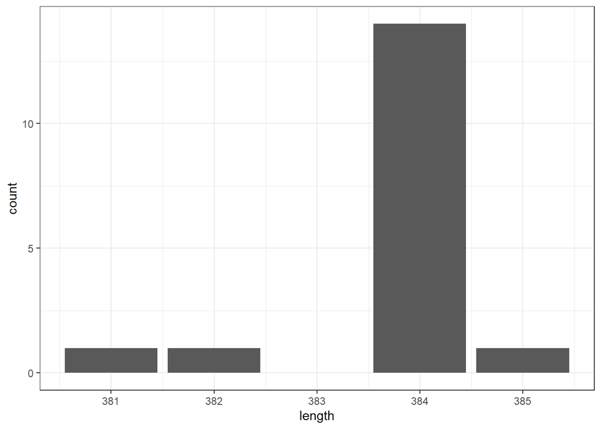

```r
final_tara_pr2 %>%
  select(seqId, length) %>%
  unique() %>%
  ggplot() +
  aes(x = length) +
  geom_histogram(bins = 100, stat = "count") +
  theme_bw()
```

```r
print("ue")
```

##### b) **TARA-MC**

1. Extraction of sequences annotated at 100% with the reference:

[length and wuery cover to be checked]

```bash
pwd: /home/lcampese/Data/metaB/V4/Blast_MC_TO/identity100

#remove the "size" part after the id of each sequence
cut -f1 -d";" Pn_tara_candi_final_pid100_list.txt > Pn_tara_candi_final_pid100_list_clean.txt


#508 sequenze

#subset the results file using my seq Ids
srun grep -Ff Pn_tara_candi_final_pid100_list_clean.txt ~/Data/metaB/V4/TARA_exploration/18S_V4_1191_samples_Pn_3readsmin.results > 18S_V4_1191_samples_Pncandi_3readsmin_pid100.results &

#324 sequenze

#extract the ids for these 324 seq
awk '{print $1}' 18S_V4_1191_samples_Pncandi_3readsmin_pid100.results > Pn_tara_candi_final_pid100_3reads_list_clean.txt

#subset the distr file using these 324 seqIds

srun grep -Ff Pn_tara_candi_final_pid100_3reads_list_clean.txt ~/Data/metaB/V4/18S_V4_1191_samples.distr > 18S_V4_1191_samples_Pncandi_3readsmin_pid100.distr &
```

There are **324** different **sequences** assigned to *Pseudonitzschia* species with a **100% identity** to MareChiara database and occurring at least **3 times** in the dataset.

2. Add the environmental information for the selected 324 sequences

```r
library(data.table)
library(tidyverse)

Pn_candi_identity100.distr <- fread("C:/Users/Userszn/Documents/PhD/script/Pseudonitzschia/metaB/V4/cfr100pid/18S_V4_1191_samples_Pncandi_3readsmin_pid100.distr")

colnames(Pn_candi_identity100.distr) <- c("seqId", "sample", "readcounts")

paste0(n_distinct(Pn_candi_identity100.distr$seqId), " sequence Ids")
```

```
## [1] "324 sequence Ids"
```

```r
Pn_candi_identity100.tax <- fread("C:/Users/Userszn/Documents/PhD/script/Pseudonitzschia/metaB/V4/cfr100pid/Pn_tara_candi_final_pid100.txt") %>%
  separate(V1, into = c("seqId", "size"), sep = ";") %>%
  rename(tax = V2, pid = V3) %>%
  select(seqId, tax, pid)

#subset tax (still with 508 seq) using the distr file (with the corret 324 seq) {the aim is to add the taxonomy info}

Pn_candi_identity100.distr.tax <- inner_join(Pn_candi_identity100.tax, Pn_candi_identity100.distr, by = "seqId")

##add env

env <- fread("C:/Users/Userszn/Documents/PhD/script/Pseudonitzschia/metaB/V4/18S_V4_1191_samples_context.tsv")

Pn_candi_identity100.distr.tax.env <- inner_join(Pn_candi_identity100.distr.tax, env) %>%
  select(seqId:readcounts,Pangaea_id:minimum.generation.time.h)


final_tara_mc <- Pn_candi_identity100.distr.tax.env %>%
  mutate(species = case_when(grepl("allochrona", tax) ~ "allochrona",
                             grepl("americana", tax) ~ "ID2_amer|cacia|circump|granii",
                             grepl("arenysensis", tax) ~ "ID1_aren|dolo|arc|subcur",
                             grepl("ID3_P._australis", tax) ~ "ID3_australis|multiseries",
                             grepl("P._australis_SPC21", tax) ~ "australis_single",
                             grepl("batesiana", tax) ~ "batesiana",
                             grepl("brasiliana", tax) ~ "ID4_brasiliana|lineola",
                             grepl("calliantha", tax) ~ "calliantha",
                             grepl("cuspidata", tax) ~ "cuspidata",
                             grepl("decipiens", tax) ~ "decipiens",
                             tax == "P._delicatissima_B653" ~ "delicatissima",
                             grepl("fraudulenta", tax) ~ "fraudulenta",
                             grepl("fukuyoi", tax) ~ "fukuyoi",
                             grepl("galaxiae", tax) ~ "galaxiae",
                             grepl("heimii", tax) ~ "heimii",
                             grepl("kodamae", tax) ~ "ID5_kodamae|lundholmiae",
                             grepl("mannii", tax) ~ "mannii",
                             grepl("micropora", tax) ~ "micropora",
                             tax == "P._multiseries_NparI_AM235380" ~ "multiseries_single",
                             grepl("multistriata", tax) ~ "multistriata",
                             tax == "P._pseudodelicatissima_B656" ~ "pseudodelicatissima",
                             grepl("pungens", tax) ~ "pungens",
                             grepl("sabit", tax) ~ "sabit",
                             grepl("turgidula", tax) ~ "turgidula",
                            TRUE ~ "ERRORE")) %>%
  mutate(length = "tobedone") %>%
  select(seqId, length, species, sample, readcounts, Station.label:Depth.chloro.max) %>%
  mutate(dataset = c("TARA-MC"))
```

#### **Comparison**

1. How big is the overlap between the two obtained datasets?

```r
#Sequences in common: Venn Diagram

tara_pr2_venn <- final_tara_pr2 %>%
  select(seqId) %>%
  mutate(`TARA-PR2` = c("1")) %>%
  unique()

tara_mc_venn <- final_tara_mc %>%
  select(seqId) %>%
  mutate(`TARA-MC` = c("1")) %>%
  unique()


print("Sequence Ids in common")
```

```
## [1] "Sequence Ids in common"
```

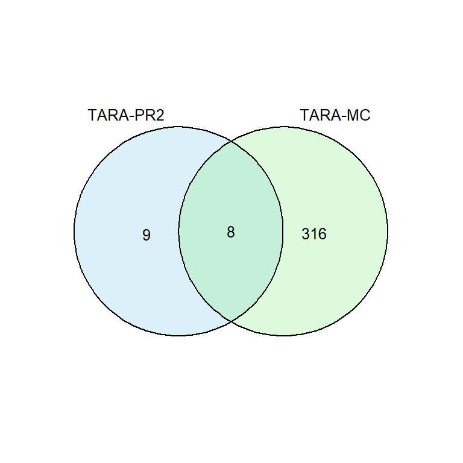

```r
full_join(tara_pr2_venn, tara_mc_venn) %>%
  replace_na(list(`TARA-PR2` = 0, `TARA-MC` = 0)) %>%
  select(-seqId) %>%
  venn::venn(ellipse = F, borders = F,  cexil = 0.8, cexsn = 0.9,
             ilcs = 0.8, sncs = 0.8, box = F, col = "black",
             zcolor = "skyblue, lightgreen")
```

```r
###species in common
tara_pr2_venn_species <- final_tara_pr2 %>%
  select(species) %>%
  mutate(`TARA-PR2` = c("1")) %>%
  unique()

tara_mc_venn_species <- final_tara_mc %>%
  select(species) %>%
  mutate(`TARA-MC` = c("1")) %>%
  unique()


print("Species in common")
```

```
## [1] "Species in common"
```

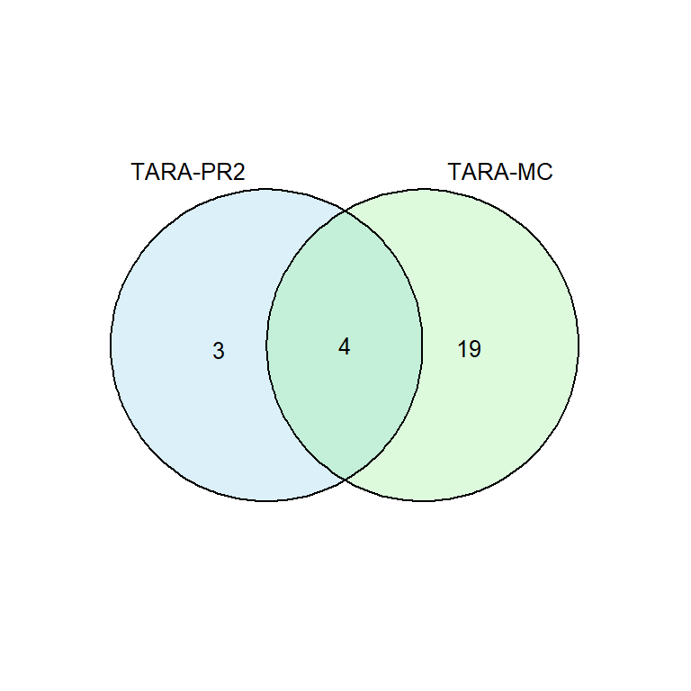

```r
full_join(tara_pr2_venn_species, tara_mc_venn_species) %>%
  replace_na(list(`TARA-PR2` = 0, `TARA-MC` = 0)) %>%
  select(-species) %>%
  venn::venn(ellipse = F, borders = F,  cexil = 0.8, cexsn = 0.9,
             ilcs = 0.8, sncs = 0.8, box = F, col = "black",
             zcolor = "skyblue, lightgreen")
```

The two datasets are quite different in the number of amplicons. **TARA-PR2** has **17 sequences**, while **TARA-MC** has **324**. There are **8 shared sequences** between the two. In terms of species, they **share 4 species**, with TARA-PR2 containing 3 species never detected in TARA-MC, and the latter with 19 species never annotated in TARA-PR2. [**]

[**] Note: MC reference has 24 species (27 sequences); 23 out of 24 are detected here. The one missing is *P. multiseries* in its “single” version (not the one in the ID3 cluster).

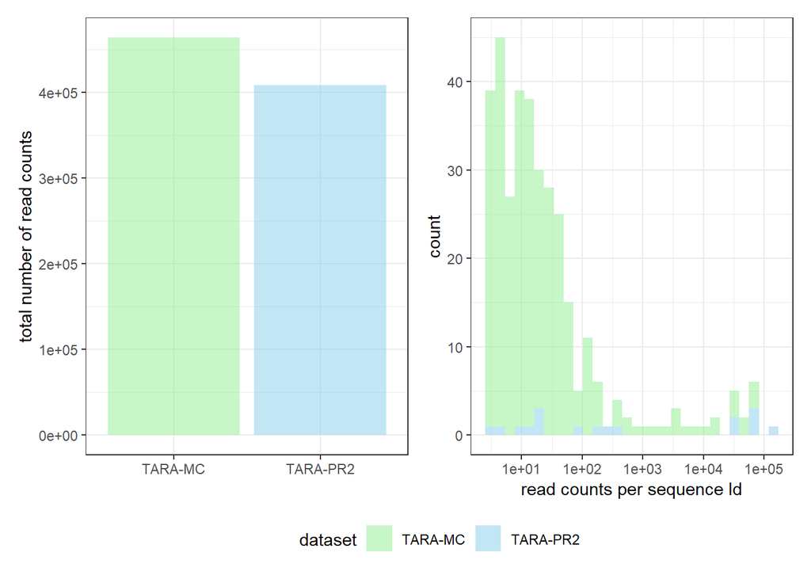

```r
plot1 <- rbind(final_tara_pr2, final_tara_mc) %>%
  group_by(dataset) %>%
  summarise(tot.numb.reads = sum(readcounts)) %>%
  ggplot() +
  aes(x=dataset, y=tot.numb.reads, fill = dataset) +
  geom_bar(stat = "identity", alpha = 0.5) +
  theme_bw() +
  scale_fill_manual(values = c("TARA-MC" = "lightgreen",
                               "TARA-PR2" = "skyblue")) +
  xlab("") +
  ylab("total number of read counts")

plot2 <-  rbind(final_tara_pr2, final_tara_mc) %>%
  mutate(Station.label = substr(Station.label, 6, 8)) %>%
  group_by(seqId, dataset) %>%
  summarise(tot.numb.reads = sum(readcounts)) %>%
  ggplot() +
  geom_histogram(aes(tot.numb.reads, fill=dataset), alpha=0.5) +
  theme(legend.position = "none") +
  theme_bw() +
  scale_x_log10() +
  xlab("read counts per sequence Id") +
  scale_fill_manual(values = c("TARA-MC" = "lightgreen",
                               "TARA-PR2" = "skyblue"))

library(patchwork)

((plot1 | plot2) & theme(legend.position = "bottom")) + plot_layout(guides = "collect")
```

The **total number of reads** (plot on the left) is higher than 400000 in both datasets, with TARA-MC containing around 50000 of reads more than TARA-PR2.

By looking at the distribution of the total number of reads per each amplicon (plot on the right), we can notice that TARA-MC has a high number of sequences with few read counts, and few very abundant sequences. This is not evident for TARA-PR2, that displays a more heterogeneous pattern.

2. How is the distribution of **richness** and **abundance** per **sampling station**?

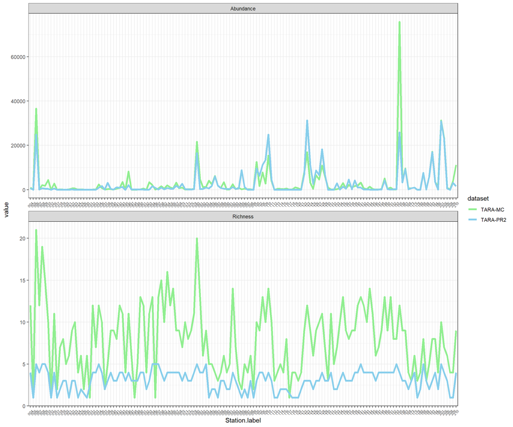

```r
rbind(final_tara_pr2, final_tara_mc) %>%
  mutate(Station.label = substr(Station.label, 6, 8)) %>%
  group_by(Station.label, dataset) %>%
  summarise(Abundance = sum(readcounts),
         Richness =n_distinct(species)) %>%
  ungroup() %>%
  pivot_longer(Abundance:Richness) %>%
  ggplot() +
  aes(x=Station.label, y=value, col=dataset, group=dataset) +
  geom_line(size=1.5) +
  theme_bw() +
  scale_color_manual(values = c("TARA-MC" = "lightgreen",
                               "TARA-PR2" = "skyblue")) +
  theme(axis.text.x = element_text(angle=50, size=6, vjust = 0.5))  +
  facet_wrap(~ name, scales = "free", nrow = 2)
```

```r
rbind(final_tara_pr2, final_tara_mc) %>%
  mutate(Station.label = substr(Station.label, 6, 8)) %>%
  group_by(Station.label, dataset) %>%
  summarise(tot.reads.station = sum(readcounts)) %>%
  ungroup() %>%
  ggplot() +
  geom_histogram(aes(tot.reads.station, fill = dataset), alpha=0.5) +
  theme_minimal() +
  theme(legend.position = "none") +
  scale_x_log10() +
  xlab("abundance per station") +
   scale_fill_manual(values = c("TARA-MC" = "lightgreen",
                               "TARA-PR2" = "skyblue")) +
  ggtitle("Pseudo-nitzschia abundance expressed as number of reads per station") +
  facet_wrap(~dataset, scales="free_y")
```

[output not shown]

- Let’s look at the **geographical distribution** of these values

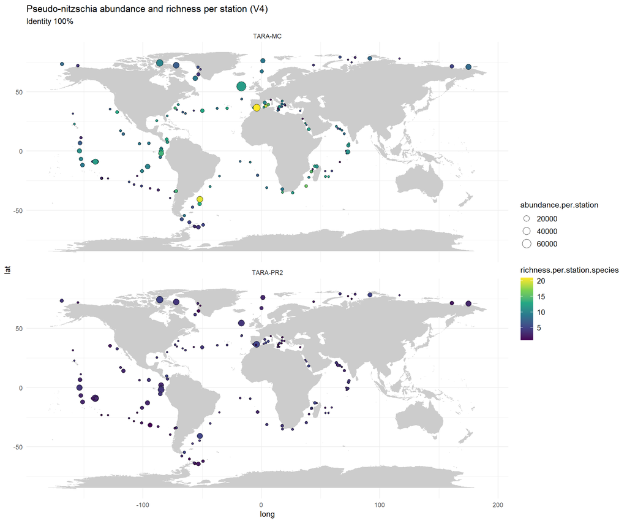

```r
library(maps)

world_map <- map_data("world")
p <- ggplot() + coord_fixed()

base_world3 <- p + geom_polygon(data=world_map,aes(x=long, y=lat,group=group),colour="gray80",size=0.2, fill="gray80")+
  theme_bw() + coord_fixed()


#map
combined_datasets_map <- rbind(final_tara_pr2, final_tara_mc) %>%
  group_by(Station.label, dataset) %>%
  mutate(Lat= mean(Latitude),
         Long=mean(Longitude),
         abundance.per.station = sum(readcounts),
         richness.per.station.amplicons = n_distinct(seqId),
         richness.per.station.species = n_distinct(species)) %>%
  ungroup() %>%
  select(seqId, species, Station.label, Lat, Long, dataset, abundance.per.station,
         richness.per.station.amplicons, richness.per.station.species) %>% unique()

base_world3+
  geom_point(data=combined_datasets_map,
             aes(x = Long, y = Lat,
                 size = abundance.per.station,
                 fill = richness.per.station.species),
                 pch = 21, col = "black") +
  scale_fill_viridis_c() +
  theme_minimal() +
  theme(legend.text=element_text(size=10)) +
  facet_wrap(~dataset, nrow = 2) +
  ggtitle("Pseudo-nitzschia abundance and richness per station (V4)",
        "Identity 100%")
```

3. Is there a **correlation** between **richness** and **abundance**?

```r
corpr2 <- rbind(final_tara_pr2, final_tara_mc) %>%
  mutate(Station.label = substr(Station.label, 6, 8)) %>%
  group_by(Station.label, dataset) %>%
  summarise(tot.reads.station = sum(readcounts),
            richness.station.spp =n_distinct(species)) %>%
  ungroup() %>%
  filter(dataset == "TARA-PR2")

corpr2.res<-psych::corr.test(corpr2$richness.station.spp, corpr2$tot.reads.station, method = "spearman")
#print(corpr2.res, short = F)

print("correlation between richness and abundance in TARA-PR2")
```

```
## [1] "correlation between richness and abundance in TARA-PR2"
```

```r
cor.test(corpr2$richness.station.spp, corpr2$tot.reads.station, method = "spearman")
```

```
##
##  Spearman's rank correlation rho
##
## data:  corpr2$richness.station.spp and corpr2$tot.reads.station
## S = 198052, p-value = 0.001136
## alternative hypothesis: true rho is not equal to 0
## sample estimates:
##       rho
## 0.2947869
```

```r
cormc <- rbind(final_tara_pr2, final_tara_mc) %>%
  mutate(Station.label = substr(Station.label, 6, 8)) %>%
  group_by(Station.label, dataset) %>%
  summarise(tot.reads.station = sum(readcounts),
            richness.station.spp =n_distinct(species)) %>%
  ungroup() %>%
  filter(dataset == "TARA-MC")


cormc.res<-psych::corr.test(cormc$richness.station.spp, cormc$tot.reads.station, method = "spearman")
#print(cormc.res, short = F)

print("correlation between richness and abundance in TARA-MC")
```

```
## [1] "correlation between richness and abundance in TARA-MC"
```

```r
cor.test(cormc$richness.station.spp, cormc$tot.reads.station, method = "spearman")
```

```
##
##  Spearman's rank correlation rho
##
## data:  cormc$richness.station.spp and cormc$tot.reads.station
## S = 199943, p-value = 5.656e-12
## alternative hypothesis: true rho is not equal to 0
## sample estimates:
##      rho
## 0.543498
```

4. Is there **spatial autocorrelation**?

```r
print("TARA-PR2")
```

```
## [1] "TARA-PR2"
```

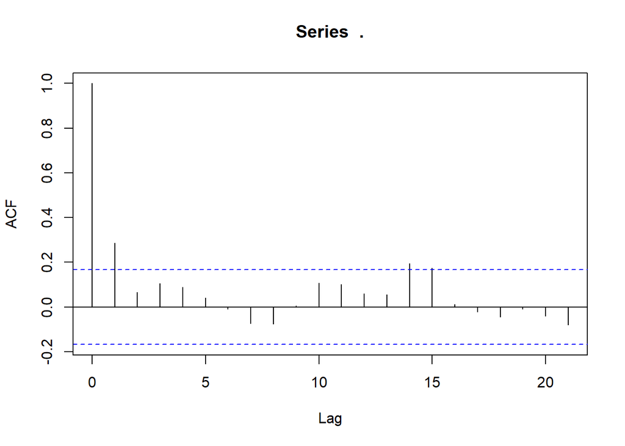

```r
final_tara_pr2 %>%
  mutate(Station.label = substr(Station.label, 6, 8)) %>%
  group_by(Station.label, dataset) %>%
  summarise(sum = sum(readcounts)) %>%
  ungroup() %>%
  arrange(Station.label) %>%
  pull(sum) %>%
  acf
```

```r
print("TARA-MC")
```

```
## [1] "TARA-MC"
```

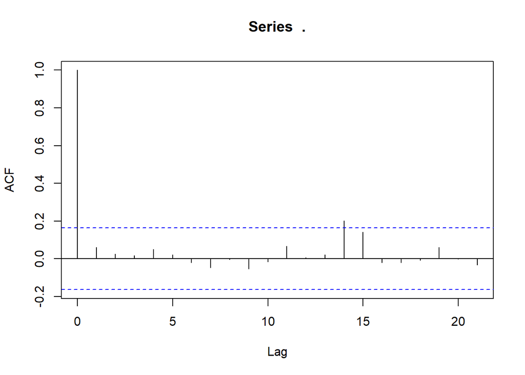

```r
final_tara_mc %>%
  mutate(Station.label = substr(Station.label, 6, 8)) %>%
  group_by(Station.label, dataset) %>%
  summarise(sum = sum(readcounts)) %>%
  ungroup() %>%
  arrange(Station.label) %>%
  pull(sum) %>%
  acf
```

The plots show thata **there is spatial autocorrelation in TARA-PR2**.

In particular, in TARA-PR2 graph (left) there is one spike at Lag = 1 that clearly falls outside the bonds, meaning that the total abundance in each station consistently influences the abundance in the following station.

Moreover, in both dataset there is a peak at 14 that slightly exceeds the outside bonds and one at 15 that almost does.

Besides that, the absence of other peaks means that the abundance per station values are overall independent of each other if only trying to explain them with themselves (the autocorrelation property).

How to deal with that? Spatial autocorrelation have implications when applying statistical methods (to be discussed).

5. What about **taxonomy**?

5.1. Is the **taxonomical annotation** of the 8 **shared sequences** the same?

```r
#common sequences: is the taxonomy the same?

cfr_taxonomy_shared <- final_tara_pr2 %>%
  select(seqId, species) %>%
  rename(PR2 = species) %>%
  inner_join(final_tara_mc[,c(1:6)]) %>%
  rename(MC = species) %>%
  select(seqId, PR2, MC) %>%
  unique() #%>%
 # mutate(MC = case_when(grepl("cuspidata", MC_0) ~ "cuspidata",
  #                          grepl("americana", MC_0) ~ "americana",
  #                          grepl("arenysensis", MC_0) ~ "arenysensis",
   #                         grepl("fraudulenta", MC_0) ~ "fraudulenta",
    #                        grepl("pungens", MC_0) ~ "pungens",
   #                         grepl("australis", MC_0) ~ "australis",
     #                       grepl("calliantha", MC_0) ~ "calliantha")) #%>%
  #select(PR2, MC)

library(kableExtra)

cfr_taxonomy_shared %>%
  kable() %>%
  kable_styling(bootstrap_options = c("striped", "hover", "condensed"))
```

| seqId | PR2 | MC |
| --- | --- | --- |
| deb50f300a767d5a5776b1c0cb9545becd8efc51 | calliantha | cuspidata |
| 937a4d3280b4226eac2d11295332b2e611552a18 | unknown | ID2_amer\|cacia\|circump\|granii |
| 62bbb4c98b04d717dd39c7c8875eb738a9a261ba | pungens | ID1_aren\|dolo\|arc\|subcur |
| aea1738fcde298b19d01ed45d7003b2b1d06ec24 | seriata | fraudulenta |
| 5981b8e5cba45a72779033ce3ed7dec99b939d28 | pseudodelicatissima | pungens |
| 361eb69c4214c48ac1350ac299fa4f220e1322bb | unknown | ID3_australis\|multiseries |
| c719f8fcd22adaffad1d3c9806984e9368cc22f4 | seriata | calliantha |
| 43095a67d10eb1d9f78cd75c28d04acb03503d28 | arenysensis | australis_single |

**The two taxonomies do not correspond**. Why?

5.2. Let’s look at the overall **taxonomic repartition** in the two datasets.

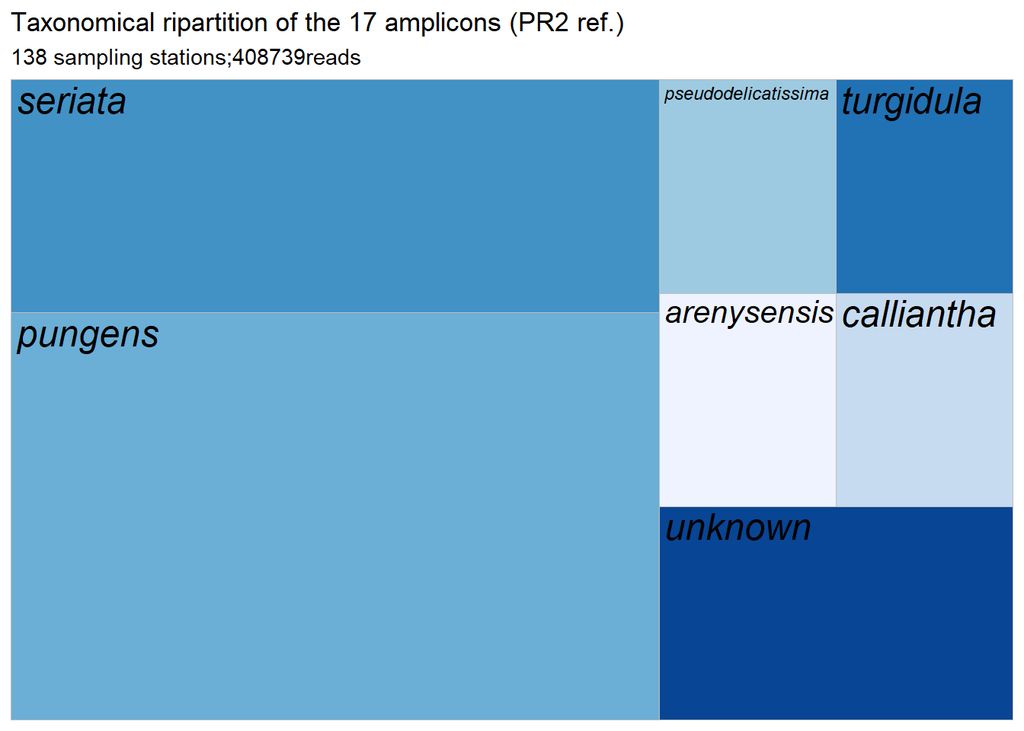

```r
library(treemapify)

final_tara_pr2 %>%
  group_by(species) %>%
  summarise(richness = n_distinct(seqId)) %>%
  ungroup() %>%
  ggplot(aes(area=richness, fill=species, label=species)) +
  geom_treemap(show.legend = F) +
 geom_treemap_text(fontface = "italic",
                    color = "black") +
                   # place = "center") +
  scale_fill_brewer(palette = "Blues") +
  ggtitle(paste0("Taxonomical ripartition of the ",
                 n_distinct(final_tara_pr2$seqId), " amplicons (PR2 ref.)"),
          paste0(n_distinct(final_tara_pr2$Station.label), " sampling stations;",
                 sum(final_tara_pr2$readcounts), "reads"))
```

```r
#final_tara_pr2 %>%
 # ggplot() +
 # aes(x = "", y = tot.numb.reads, fill = species) +
 # geom_bar(width = 1, stat = "identity") +
 # coord_polar("y", start=0) +
 # theme_bw() +
 # scale_fill_brewer(palette = "Paired") +
```

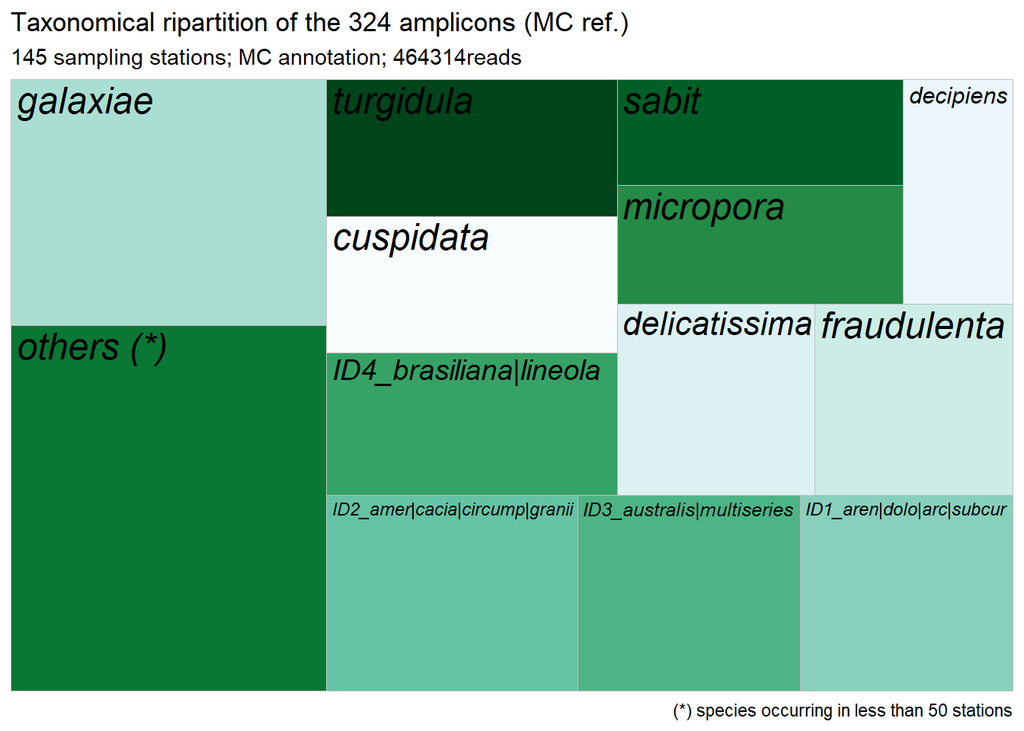

```r
#tassonomia mia:
library(RColorBrewer)

nb.cols <- 13
mycolors <- colorRampPalette(brewer.pal(9,"BuGn"))(nb.cols)

final_tara_mc %>%
  group_by(species) %>%
  summarise(richness = n_distinct(seqId),
            occupancy = n_distinct(Station.label)) %>%
  ungroup() %>%
  mutate(species_sel = ifelse(occupancy < 50, "others (*)",
                              species)) %>%
  ungroup() %>%
  group_by(species_sel) %>%
  summarise(richness2 = sum(richness)) %>%
  ggplot(aes(area=richness2, fill=species_sel, label=species_sel)) +
  geom_treemap(show.legend = F) +
  geom_treemap_text(fontface = "italic",
                    color = "black") +
  # place = "center") +
  #scale_fill_brewer(palette = "BuGn") +
  scale_fill_manual(values = mycolors) +
  ggtitle(paste0("Taxonomical ripartition of the ",
                 n_distinct(final_tara_mc$seqId), " amplicons (MC ref.)"),
          paste0(n_distinct(final_tara_mc$Station.label), " sampling stations; MC annotation; ",
                 sum(final_tara_mc$readcounts), "reads")) +
  labs(caption = "(*) species occurring in less than 50 stations")
```

```r
print("ue")
```

5.3. Let’s look at the **geographical distribution** of the species

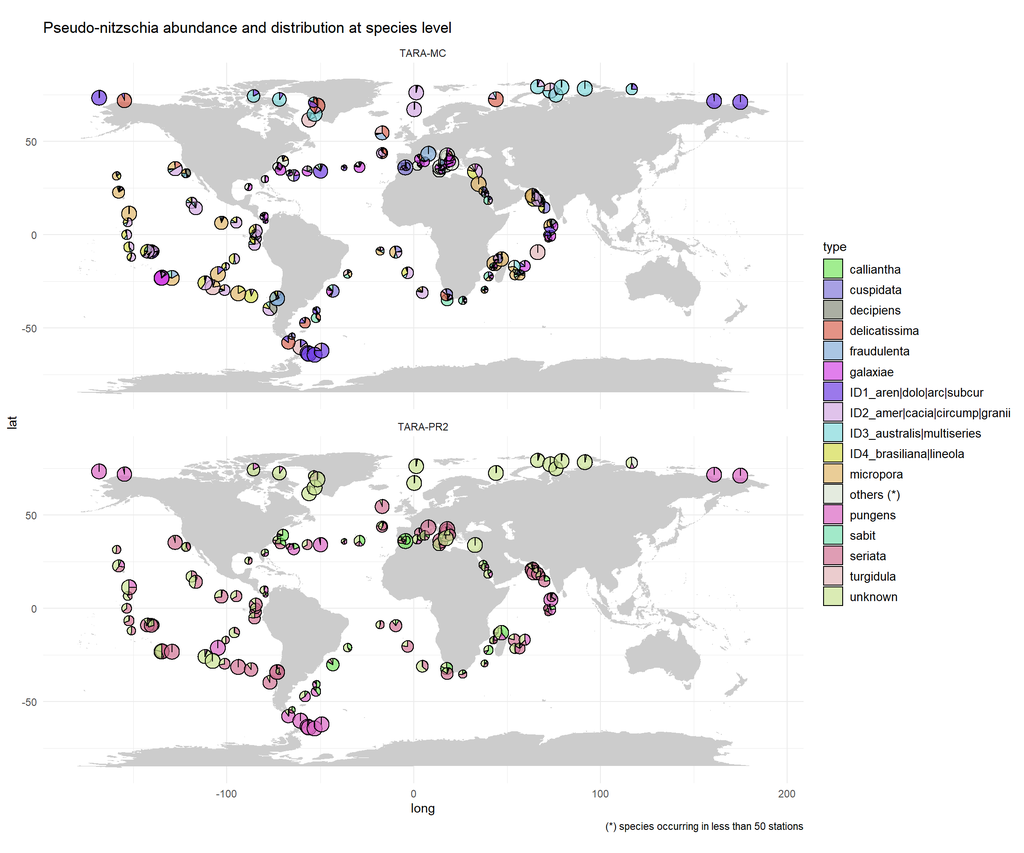

```r
###devo unirli in un unico file e facewrappare tutto:


library(scatterpie)

combined_datasets_mappie <- rbind(final_tara_pr2, final_tara_mc) %>%
  group_by(Station.label, dataset) %>%
  mutate(tot.abundance.per.station = sum(readcounts),
         Lat = mean(Latitude),
         Long = mean(Longitude)) %>%
  ungroup() %>%
  group_by(species, dataset) %>%
  mutate(occupancy = n_distinct(Station.label)) %>%
  ungroup() %>%
  mutate(species_sel = ifelse(occupancy < 50, "others (*)",
                              as.character(species))) %>%
  group_by(species_sel, Station.label, dataset) %>%
  mutate(sel.species.abundance.per.station = sum(readcounts),
         fraction = sel.species.abundance.per.station/tot.abundance.per.station) %>%
  ungroup() %>%
  select(Station.label, Long, Lat, species_sel, fraction, dataset) %>%
  arrange(Station.label) %>%
  unique()  %>%
  group_by(Station.label) %>%
  mutate(radius = max(fraction)*4) %>%
  ungroup() %>%
  spread(species_sel, fraction) %>%
  mutate_all(funs(ifelse(is.na(.), 0, .)))


mypalette <- randomcoloR::distinctColorPalette(17)

base_world3 +
  geom_scatterpie(aes(x=Long, y=Lat, r=radius),
                  data=combined_datasets_mappie,
                 # cols= c("arenysensis", "calliantha", "cuspidata", "pungens",
                #          "seriata", "unknown", "americana",
                #          "australis", "micropora", "delicatissima",
                 #         "galaxiae", "brasiliana", "others (*)"),
                  #alpha=.7) +
                cols = c("calliantha", "cuspidata", "decipiens","delicatissima",
                         "fraudulenta", "galaxiae", "ID1_aren|dolo|arc|subcur",
                         "ID2_amer|cacia|circump|granii", "ID3_australis|multiseries",
                         "ID4_brasiliana|lineola", "micropora", "others (*)",
                         "pungens", "sabit", "seriata", "turgidula", "unknown"),
                         alpha = .7) +
  theme_minimal() +
  theme(legend.text=element_text(size=10)) +
  coord_fixed() +
 # scale_fill_brewer(palette = "Paired") +
  scale_fill_manual(values = mypalette) +
  facet_wrap(~dataset, nrow = 2) +
  ggtitle("Pseudo-nitzschia abundance and distribution at species level")  +
  labs(caption = "(*) species occurring in less than 50 stations")
```

```r
#+
  #geom_scatterpie_legend(combined_datasets_mappie$radius, x=-150, y=-70)
```

6. What about **size classes**? Which one holds the highest number of sequences? Is there overlap among different classes?

```r
print("Combining the two dataset; Overlap considering seqId")
```

```
## [1] "Combining the two dataset; Overlap considering seqId"
```

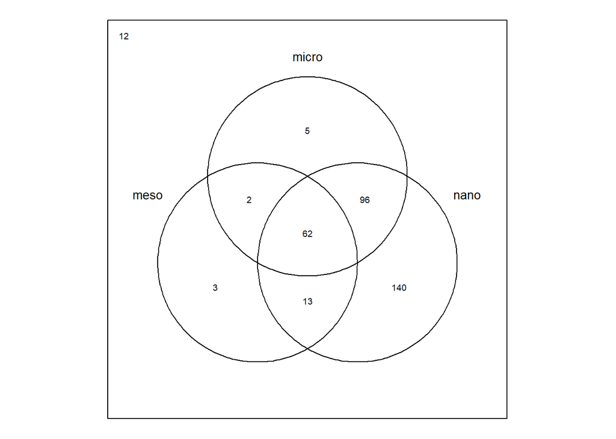

```r
rbind(final_tara_pr2, final_tara_mc) %>%
  unite("Fraction.size", lower.size.fraction:upper.size.fraction, sep = "-") %>%
  mutate(Fraction.size = case_when(Fraction.size %in% c("3-20", "5-20") ~ "nano",
                                 Fraction.size == "20-180" ~ "micro",
                                 Fraction.size == "180-2000" ~ "meso",
                                 TRUE ~ "other")) %>%
  select(seqId, readcounts, Fraction.size) %>%
  group_by(seqId, Fraction.size) %>%
  summarise(sum = sum(readcounts)) %>%
  ungroup() %>%
  mutate(sum = ifelse(sum > 0,  1, 0)) %>%
  spread(Fraction.size, sum) %>%
  mutate_at(vars(-seqId), funs(ifelse(is.na(.), 0, .))) %>%
  select(-c("seqId", "other")) %>%
  venn::venn(ellipse = F, borders = F,  cexil = 0.8, cexsn = 0.9)
```

## Extras

##### Occurrence of sequences

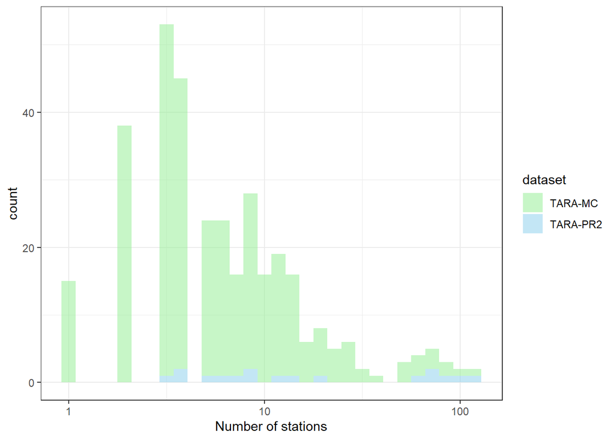

```r
rbind(final_tara_pr2, final_tara_mc) %>%
  mutate(Station.label = substr(Station.label, 6, 8)) %>%
  group_by(seqId, dataset) %>%
  summarise(occurrence = n_distinct(Station.label)) %>%
  ggplot() +
  geom_histogram(aes(occurrence, fill=dataset), alpha=0.5) +
  theme(legend.position = "none") +
  theme_bw() +
  scale_x_log10() +
  xlab("Number of stations") +
  scale_fill_manual(values = c("TARA-MC" = "lightgreen",
                               "TARA-PR2" = "skyblue"))
```

```r
rbind(final_tara_pr2, final_tara_mc) %>%
  mutate(Station.label = substr(Station.label, 6, 8)) %>%
  group_by(seqId, dataset) %>%
  summarise(occurrence = n_distinct(Station.label)) %>%
  filter(occurrence <2)
```

```
## # A tibble: 15 x 3
## # Groups:   seqId [15]
##    seqId                                    dataset occurrence
##    <chr>                                    <chr>        <int>
##  1 0f3871ae419e562ec7d25b2c261b399d6f890239 TARA-MC          1
##  2 1df3fdd9440ebbf36a65fb17cfa6256a0d800155 TARA-MC          1
##  3 1f9b027ed0145587504f31e42d83820e6a3ed887 TARA-MC          1
##  4 43d6dbb857d693745cdf04f3423a16b9f38228f7 TARA-MC          1
##  5 64d64d2b30a54732f00313b3b1b602cadbe7ab10 TARA-MC          1
##  6 8700edd2a375004f8084b47c1623b7b7a904e4bc TARA-MC          1
##  7 9cc3affd02f5f38ea682e1f998dc8d029e4a8c76 TARA-MC          1
##  8 b912d745af81c8293695d0b15ed59747a3006454 TARA-MC          1
##  9 d9cebf3d6215133c663ea09389f0b6bd5056595a TARA-MC          1
## 10 e2b2dca71ed47cf4b64724396f893ee347951d43 TARA-MC          1
## 11 f337bd79d9bcb590687e3a1d466af4faedead385 TARA-MC          1
## 12 f5bbd35da64dc9ddde84e152ab86c16962e25440 TARA-MC          1
## 13 f9ffb1509365893d90dd736052928ca78c7b2bed TARA-MC          1
## 14 ff36e60b70240166e7936d883d5a4b99cfa08821 TARA-MC          1
## 15 ffd89634c5c01ed720e37899a3d585395768050b TARA-MC          1
```

There are 15 sequences occurring only in one station.

##### **Explore PR2 Database**

```bash
#1. Extract Pseudonitzschia sequences from the the whole PR2 database
#OLD PR2 VERSION : I leave it here, but commented, just as reminder

/home/lcampese/Data/metaB/V4

#srun zcat pr2_version_4.11.1_UniEuk_V4_unique.tsv.gz | grep Pseudo-nitzschia > pr2_version_4.11.1_UniEuk_V4_unique_Pn.tsv &


#extract pn from the fas file, replace the symbol ">" (header) with boh, una virgola? anyway remove it so that R can open it
srun grep "Pseudo-nitzschia" 46345_EukRibo_V4_2020-10-27.fas | grep "^>" | sed -e 's/>//' -e 's/;/,/g' > 46345_EukRibo_V4_2020-10-27_Pn.txt &
```

Extracting Pseudo-nitzschia sequences from the latest version of PR2 dataset: 17 sequences.

```r
library(data.table)
library(tidyverse)

#pr2_pn <- fread("C:/Users/Userszn/Documents/PhD/script/Pseudonitzschia/metaB/V4/pr2_version_4.11.1_UniEuk_V4_unique_Pn.tsv", header  = FALSE)

pr2_pn <- fread("C:/Users/Userszn/Documents/PhD/script/Pseudonitzschia/metaB/V4/NEW_PR2_taxonomyfixed/46345_EukRibo_V4_2020-10-27_Pn.txt",
                     header = F)

#colnames(pr2_pn) <- c("lineage", "sequence", "taxogroup1", "taxogroup2", "PR2_id", "GenBank_ID")

#pr2_pn_final <- splitstackshape::cSplit(pr2_pn, "lineage", "|") %>%
#  mutate(species = ifelse(is.na(lineage_13), "Pseudo-nitzschia+unknown",
#                          as.character(lineage_13))) %>%
#  select(-lineage_13) %>%
#  splitstackshape::cSplit("species", "+") %>%
#  rename(species = species_2) %>%
#  mutate(seq_length = nchar(sequence)) %>%
#  select(sequence, seq_length, species, PR2_id, GenBank_ID)


pr2_pn_final <- pr2_pn%>%
  separate(V1, into = c("GenBank_Id", "Domain"), sep = " ") %>%
  rename(species = V13) %>%
  select(GenBank_Id, species)



#paste0(n_distinct(pr2_pn_final$sequence), " identical sequences")
paste0(n_distinct(pr2_pn_final$species), " species detected")
```

```
## [1] "6 species detected"
```

```r
#paste0(n_distinct(pr2_pn_final$PR2_id), " PR2 IDs")
paste0(n_distinct(pr2_pn_final$GenBank_Id), " GenBank Ids")
```

```
## [1] "17 GenBank Ids"
```

```r
###DA QUA IN POI NON HO AGGIORNATO

#pr2_pn_final1<- splitstackshape::cSplit(pr2_pn_final, "GenBank_ID", ",")


#genbank_abb <- as.data.frame(lapply(pr2_pn_final1[,5:9], function(y) gsub("\\..*", "", y)))

pr2_pn_final2 <- pr2_pn_final1 %>%
  select(sequence:PR2_id) %>%
  cbind(genbank_abb)


pr2_pn_final3 <- pr2_pn_final2 %>%
  pivot_longer(GenBank_ID_1:GenBank_ID_5) %>%
  #mutate(ID = ifelse(grepl("GenBank", name), "GenBank_ID", "altro")) %>%
  select(-name) %>%
  rename(GenBank_ID = value) %>%
  na.omit()

write.csv(pr2_pn_final3, "C:/Users/Userszn/Documents/PhD/script/Pseudonitzschia/metaB/V4/pr2_pn_final3.csv", row.names = F)

pr2_pn_final_genbankinfo <- read.csv("C:/Users/Userszn/Documents/PhD/script/Pseudonitzschia/metaB/V4/pr2_pn_final_genbankinfo.csv") %>% na.omit()

pr2_pn_final_genbankinfo %>%
  select(species, PR2_id, GenBank_ID_input, Origin) %>%
  mutate(colture = ifelse(Origin == "cultured", 1, 0)) %>%
  group_by(species) %>%
  summarise(PR2 = n_distinct(PR2_id),
            GenBank = n_distinct(GenBank_ID_input),
            GenBank_cultured = sum(colture)) %>%
  ungroup() %>%
  mutate(GenBank_uncultured = GenBank - GenBank_cultured) %>%
  select(-GenBank) %>%
  pivot_longer(PR2:GenBank_uncultured) %>%
  rename(ID = name) %>%
  ggplot() +
  aes(x=value, y=reorder(species, desc(species)), fill=ID) +
  geom_bar(stat="identity", position = "dodge") +
  theme_bw() +
  xlab("") +
  ylab("") +
  #scale_fill_manual(values = c("PR2" = "tomato",
   #                            "GenBank_cultured" = "forestgreen",
  #                             "GenBank_uncultured" = "olivedrab3")) +
  scale_x_continuous(breaks=c(1, 3, 5, 7, 9, 11 )) +
  ggtitle(paste0(n_distinct(pr2_pn_final2$PR2_id), " Reference Ids (PR2)"))
```